# Practica Opciones y Arboles Binomiales - Lab1

Lesly Vásquez, Daniela Durango

2025-04-07

> Conversión a R Markdown del documento publicado en RPubs (https://rpubs.com/LeslyV/1294100). Código optimizado para memoria: todo el flujo se encapsula en funciones vectorizadas (sin `bind_rows` dentro de ciclos, sin guardar matrices intermedias por activo) y se repite el mismo ejercicio para Corning (GLW) y Apple (AAPL) en la sección 12. Requiere conexión a internet (`tq_get` descarga precios de Yahoo Finance).

# 0. Funciones (se reutilizan en ambos ejercicios)

```r
# --- Datos: precios ajustados + retornos log diarios (solo columnas necesarias) ---
descargar_datos <- function(tick, start, end) {
  precios <- tq_get(tick, from = start, to = end, get = "stock.prices") %>%
    select(symbol, date, adjusted)
  ret <- precios %>%
    group_by(symbol) %>%
    tq_transmute(select = adjusted, mutate_fun = periodReturn,
                 period = "daily", col_rename = "ret", type = "log") %>%
    ungroup()
  ret_xts <- ret %>%
    pivot_wider(names_from = symbol, values_from = ret) %>%
    tk_xts(date_var = date, silent = TRUE)
  ret_xts <- ret_xts[, tick]                       # mismo orden que 'tick'
  ultimo <- precios %>% group_by(symbol) %>% slice_max(date, n = 1) %>% ungroup()
  list(precios = precios, ret = ret, ret_xts = ret_xts,
       latest_prices = setNames(ultimo$adjusted, ultimo$symbol)[tick])
}

# --- Media-varianza por Monte Carlo (vectorizado, sin ciclo for) ---
min_varianza <- function(ret_xts, num_port = 5000, seed = 123) {
  tick <- colnames(ret_xts); k <- length(tick)
  cov_mat  <- cov(ret_xts) * 252
  mean_ret <- colMeans(ret_xts)
  set.seed(seed)
  W <- matrix(runif(num_port * k), ncol = k, byrow = TRUE, dimnames = list(NULL, tick))
  W <- W / rowSums(W)
  ret_p  <- (drop(W %*% mean_ret) + 1)^252 - 1
  risk_p <- sqrt(rowSums((W %*% cov_mat) * W))
  best <- which.min(risk_p)
  list(cov_mat = cov_mat, mean_ret = mean_ret,
       media_var = as_tibble(W[best, , drop = FALSE]) %>%
         mutate(Return = ret_p[best], Risk = risk_p[best], SharpeRatio = ret_p[best] / risk_p[best]),
       weights = W[best, ])
}

# --- MGB: acumula directo el valor del portafolio (no guarda una matriz por activo) ---
simular_portafolio <- function(S0, shares, mu, sigma, Nsim = 5000, trimestres = 8,
                               dt = 0.25, seed = 123) {
  set.seed(seed)
  port <- matrix(0, nrow = trimestres + 1, ncol = Nsim)
  for (a in names(S0)) {
    z <- matrix(rnorm(trimestres * Nsim), nrow = trimestres, byrow = TRUE)
    inc <- (mu[a] - 0.5 * sigma[a]^2) * dt + sigma[a] * sqrt(dt) * z
    port <- port + shares[a] * S0[a] * exp(rbind(0, apply(inc, 2, cumsum)))
  }
  port
}

# --- Retorno, volatilidad y VaR trimestral ---
analizar_var <- function(port) {
  R  <- diff(log(port))                     # trimestres x Nsim
  v0 <- mean(port[1, ])
  q  <- apply(R, 1, quantile, probs = c(0.01, 0.05), na.rm = TRUE)
  tibble(
    Trimestre = seq_len(nrow(R)),
    `Retorno Esperado (%)`     = round(rowMeans(R) * 100, 3),
    `Volatilidad Esperada (%)` = round(apply(R, 1, sd) * 100, 3),
    `VaR 1% (USD)` = round(-q[1, ] * v0, 2),
    `VaR 5% (USD)` = round(-q[2, ] * v0, 2)
  )
}

# --- Árbol binomial vectorizado: memoria O(n) en vez de matriz (n+1)x(n+1) ---
binomial_option <- function(S, K, r, T, sigma, n, tipo = "call", americana = FALSE) {
  S <- unname(S); K <- unname(K); sigma <- unname(sigma)
  dt <- T / n; u <- exp(sigma * sqrt(dt)); d <- 1 / u
  p <- (exp(r * dt) - d) / (u - d); disc <- exp(-r * dt)
  sgn <- if (tipo == "call") 1 else -1
  v <- pmax(sgn * (S * u^(0:n) * d^(n:0) - K), 0)
  for (j in (n - 1):0) {
    v <- disc * (p * v[2:(j + 2)] + (1 - p) * v[1:(j + 1)])
    if (americana) v <- pmax(v, sgn * (S * u^(0:j) * d^(j:0) - K))
  }
  v[1]
}

valuar_opciones <- function(S0, sigma, r, T, n) {
  a <- names(S0)
  tibble(Accion = a, Spot = unname(S0),
         Call_Euro = vapply(a, function(x) binomial_option(S0[x], S0[x], r, T, sigma[x], n), numeric(1)),
         Call_Amer = vapply(a, function(x) binomial_option(S0[x], S0[x], r, T, sigma[x], n, americana = TRUE), numeric(1)))
}

rolling_calls <- function(valor_esperado, sigma, r, T, n, trimestres) {
  g <- expand.grid(Accion = names(sigma), Trimestre = seq_len(trimestres), stringsAsFactors = FALSE)
  g$Valor_Call <- mapply(function(t, a) {
    S <- valor_esperado[t]; binomial_option(S, S, r, T, sigma[a], n)
  }, g$Trimestre, g$Accion)
  as_tibble(g[, c("Trimestre", "Accion", "Valor_Call")])
}

graficar_arbol <- function(S, sigma, T = 1, n = 3, titulo = "Árbol Binomial") {
  u <- exp(unname(sigma) * sqrt(T / n)); d <- 1 / u
  nodos <- expand.grid(i = 0:n, j = 0:n) %>% filter(i + j <= n) %>%
    mutate(Precio = unname(S) * u^i * d^j, name = paste(i, j, sep = ","))
  e <- filter(nodos, i + j < n)
  edges_df <- data.frame(from = rep(e$name, 2),
                         to   = c(paste(e$i + 1, e$j, sep = ","), paste(e$i, e$j + 1, sep = ",")))
  g <- graph_from_data_frame(edges_df, vertices = select(nodos, name, Precio), directed = TRUE)
  ggraph(g, layout = "tree") +
    geom_edge_link() +
    geom_node_label(aes(label = round(Precio, 2))) +
    labs(title = titulo) +
    theme_void()
}

# Parámetros comunes
start <- as.Date("2022-06-01")
end <- as.Date("2025-03-31")
investment <- 1e6
r <- 0.0372; n <- 3; T_opc <- 2
Nsim <- 5000; trimestres <- 8
cobertura_pct <- 0.85
```

**Interpretación:** Todas las etapas del análisis se definen una sola vez como funciones. Así, el ejercicio se puede repetir con otras acciones sin duplicar código ni acumular objetos en memoria.

# 1. Parámetros generales

```r
tick <- c("MLGO", "NCNO", "CORT")
```

**Interpretación:** Se definen los símbolos de las acciones a analizar y el rango de tiempo para obtener los datos históricos.

# 2. Carga de precios históricos (2022-06-01 a 2025-03-31)

```r
datos <- descargar_datos(tick, start, end)
latest_prices <- datos$latest_prices

#Precios históricos (primeras filas)
head(datos$precios)
```

| symbol | date | adjusted |
| --- | --- | --- |
| MLGO | 2022-06-01 | 61380 |
| MLGO | 2022-06-02 | 61380 |
| MLGO | 2022-06-03 | 61320 |
| MLGO | 2022-06-06 | 61380 |
| MLGO | 2022-06-07 | 61440 |
| MLGO | 2022-06-08 | 61440 |

```r
#Retornos logaritmicos (primeras filas)
head(datos$ret_xts)
```

```
##                     MLGO         NCNO        CORT
## 2022-06-01  0.0000000000  0.000000000 0.000000000
## 2022-06-02  0.0000000000  0.136455899 0.012458246
## 2022-06-03 -0.0009779952 -0.021766863 0.016997605
## 2022-06-06  0.0009779952 -0.032557766 0.002805026
## 2022-06-07  0.0009770396  0.038113251 0.000000000
## 2022-06-08  0.0000000000  0.006075722 0.007905183
```

**Interpretación:** Se descargan los precios ajustados y se calculan los retornos logarítmicos diarios para cada acción.

# 3. Visualización de retornos

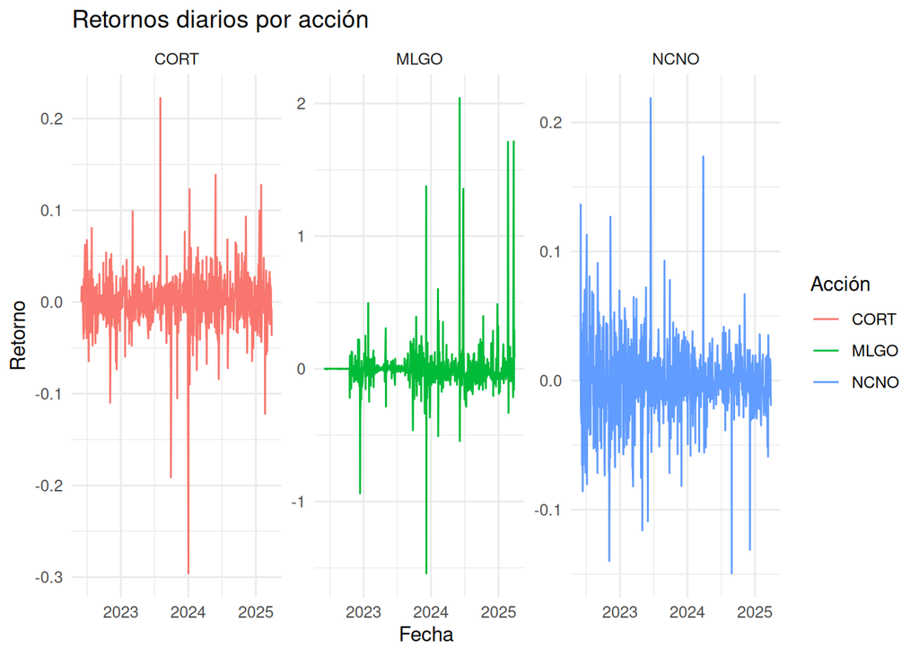

```r
ggplot(datos$ret, aes(x = date, y = ret, color = symbol)) +
  geom_line() +
  facet_wrap(~symbol, scales = "free_y") +
  labs(title = "Retornos diarios por acción", x = "Fecha", y = "Retorno", color = "Acción") +
  theme_minimal()
```

**Interpretación:** Se visualizan los retornos diarios por acción, lo cual permite evidenciar su volatilidad y comportamiento temporal.

# 4. Portafolio de media varianza

```r
mv <- min_varianza(datos$ret_xts, num_port = 5000)
weights_media <- mv$weights
sigma_annual  <- sqrt(diag(mv$cov_mat))
mu_annual     <- mv$mean_ret * 252
mv$cov_mat
```

```
##            MLGO       NCNO       CORT
## MLGO 8.75499648 0.04685761 0.03001821
## NCNO 0.04685761 0.25139723 0.04889222
## CORT 0.03001821 0.04889222 0.24013522
```

```r
mv$media_var
```

| MLGO | NCNO | CORT | Return | Risk | SharpeRatio |
| --- | --- | --- | --- | --- | --- |
| 0.01435587 | 0.4775098 | 0.5081343 | 0.142612 | 0.3820164 | 0.3733138 |

**Interpretación:** Se optimiza un portafolio de mínima varianza generando múltiples combinaciones de pesos y se elige aquella con menor riesgo.

# 5. Distribución de $1 millón de dólares

```r
shares <- investment * weights_media / latest_prices
shares
```

```
##        MLGO        NCNO        CORT
##    27.58092 16511.40465  9301.37829
```

**Interpretación:** Se determina la cantidad de acciones a comprar con una inversión total de USD 1 millón, de acuerdo con los pesos óptimos.

# 6. Simulación MGB desde 2025-04-01 hasta 2027-04-01 (5000 simulaciones por acción)

```r
portfolio_sim <- simular_portafolio(latest_prices, shares, mu_annual, sigma_annual,
                                    Nsim = Nsim, trimestres = trimestres)
sim_summary <- tibble(Trimestre = 0:trimestres, Valor_Esperado = rowMeans(portfolio_sim))
sim_summary
```

| Trimestre | Valor_Esperado |
| --- | --- |
| 0 | 1000000 |
| 1 | 1040327 |
| 2 | 1084346 |
| 3 | 1134704 |
| 4 | 1185835 |
| 5 | 1249029 |
| 6 | 1319158 |
| 7 | 1394164 |
| 8 | 1478560 |

**Interpretación:** Se simula la evolución del portafolio durante 2 años, proyectando el valor del portafolio en cada trimestre mediante MGB.

# 7. Análisis de Retorno, Volatilidad y VaR

```r
analisis_trimestral <- analizar_var(portfolio_sim)
rm(portfolio_sim); invisible(gc())        # libera la matriz de simulaciones

kable(analisis_trimestral, caption = "Análisis Trimestral del Portafolio Simulado") %>%
  kable_styling()
```

Análisis Trimestral del Portafolio Simulado

| Trimestre | Retorno Esperado (%) | Volatilidad Esperada (%) | VaR 1% (USD) | VaR 5% (USD) |
| --- | --- | --- | --- | --- |
| 1 | 2.382 | 17.740 | 399100.3 | 269140.7 |
| 2 | 2.559 | 18.038 | 398265.6 | 267759.0 |
| 3 | 2.718 | 18.318 | 398796.3 | 269687.0 |
| 4 | 2.816 | 18.305 | 381522.7 | 263831.5 |
| 5 | 3.130 | 19.226 | 427904.6 | 283767.3 |
| 6 | 3.470 | 19.166 | 408503.7 | 274142.3 |
| 7 | 3.475 | 19.026 | 396619.9 | 276934.1 |
| 8 | 3.602 | 19.564 | 405781.9 | 277210.0 |

**Interpretación:** Se evalúa el comportamiento del portafolio en términos de retorno, riesgo y pérdida máxima esperada (VaR) por trimestre.

# 8. Cobertura con Opciones Europeas y Americanas (Árbol Binomial)

```r
option_data <- valuar_opciones(latest_prices, sigma_annual, r, T_opc, n)
kable(option_data, caption = "Opciones Europeas y Americanas - Valoración con Árbol Binomial") %>%
  kable_styling()
```

Opciones Europeas y Americanas - Valoración con Árbol Binomial

| Accion | Spot | Call_Euro | Call_Amer |
| --- | --- | --- | --- |
| MLGO | 520.50 | 501.388126 | 501.388126 |
| NCNO | 28.92 | 9.395043 | 9.395043 |
| CORT | 54.63 | 17.410973 | 17.410973 |

**Interpretación:** Se valúan las opciones europeas y americanas tipo call mediante el modelo binomial con 3 pasos.

# 9. Rolling trimestral de opciones Call Europeas

```r
call_rolling <- rolling_calls(sim_summary$Valor_Esperado, sigma_annual, r, T_opc, n, trimestres)
kable(call_rolling, caption = "Rolling Trimestral de Opciones Call Europeas") %>%
  kable_styling()
```

Rolling Trimestral de Opciones Call Europeas

| Trimestre | Accion | Valor_Call |
| --- | --- | --- |
| 1 | MLGO | 963281.7 |
| 1 | NCNO | 324863.2 |
| 1 | CORT | 318707.2 |
| 2 | MLGO | 1002127.5 |
| 2 | NCNO | 337963.8 |
| 2 | CORT | 331559.5 |
| 3 | MLGO | 1044530.6 |
| 3 | NCNO | 352264.1 |
| 3 | CORT | 345588.8 |
| 4 | MLGO | 1093039.2 |
| 4 | NCNO | 368623.4 |
| 4 | CORT | 361638.2 |
| 5 | MLGO | 1142293.6 |
| 5 | NCNO | 385234.3 |
| 5 | CORT | 377934.3 |
| 6 | MLGO | 1203166.7 |
| 6 | NCNO | 405763.5 |
| 6 | CORT | 398074.5 |
| 7 | MLGO | 1270720.8 |
| 7 | NCNO | 428545.9 |
| 7 | CORT | 420425.1 |
| 8 | MLGO | 1342972.3 |
| 8 | NCNO | 452912.4 |
| 8 | CORT | 444329.9 |

**Interpretación:** Se realiza la evaluación trimestral de opciones Call Europeas con strike ajustado al spot, para hacer cobertura dinámica.

# 10. Visualización del árbol binomial (Call Europea)

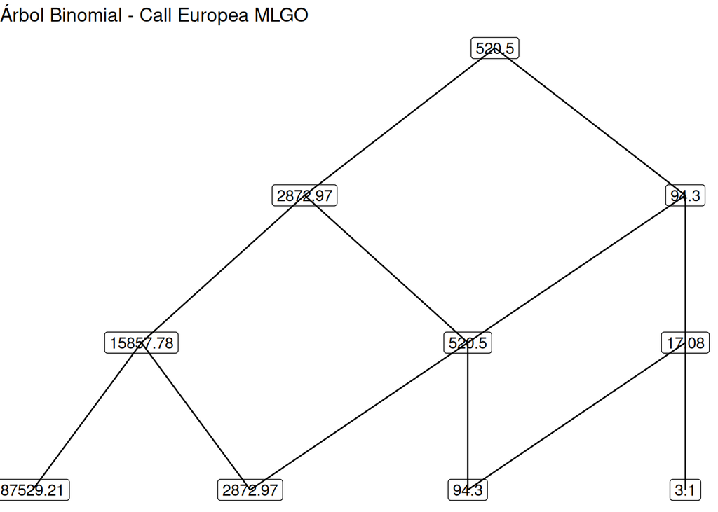

```r
graficar_arbol(latest_prices["MLGO"], sigma_annual["MLGO"], T = 1, n = 3,
               titulo = "Árbol Binomial - Call Europea MLGO")
```

**Interpretación:** Se visualiza la estructura del árbol binomial para una Call Europea, mostrando la evolución esperada de precios.

# 11. Cobertura financiera y distribución entre activos

```r
cobertura_dist <- cobertura_pct * investment * weights_media
cobertura_dist
```

```
##      MLGO      NCNO      CORT
##  12202.49 405883.35 431914.16
```

**Interpretación:** Se define una estrategia de cobertura trimestral del 85% del portafolio, distribuida según los pesos óptimos en acciones.

# Justificación final

Se desarrolló una estrategia de inversión diversificada usando media-varianza, simulación de precios mediante MGB y análisis de riesgo con VaR. La cobertura se realizó mediante opciones Call Europeas evaluadas con árboles binomiales, con rolling trimestral, y se definió un porcentaje fijo de cobertura con distribución proporcional. Esta metodología permite gestionar de forma activa el riesgo y proyectar el valor del portafolio con fundamentos sólidos.

## ¿Cómo se divide el dinero para la cobertura de las opciones?

El monto destinado a la cobertura se calculó como el 85% del total del portafolio. Luego, este valor se distribuyó entre las acciones del portafolio en proporción a los pesos de mínima varianza asignados a cada activo. Esto asegura que la cobertura sea coherente con la estructura del portafolio base.

# 12. Mismo ejercicio con Corning (GLW) y Apple (AAPL)

```r
# Libera los objetos del primer ejercicio antes de empezar
rm(datos, mv, weights_media, sigma_annual, mu_annual, shares, sim_summary,
   analisis_trimestral, option_data, call_rolling, cobertura_dist, latest_prices)
invisible(gc())
```

## 12.1 Parámetros generales

```r
tick_g <- c("GLW", "AAPL")
```

**Interpretación:** Se analizan Corning (GLW) y Apple (AAPL) en el mismo periodo (2022-06-01 a 2025-03-31) y con los mismos supuestos del ejercicio anterior.

## 12.2 Carga de precios históricos

```r
datos_g <- descargar_datos(tick_g, start, end)
latest_prices_g <- datos_g$latest_prices
head(datos_g$precios)
```

| symbol | date | adjusted |
| --- | --- | --- |
| GLW | 2022-06-01 | 31.92583 |
| GLW | 2022-06-02 | 32.88973 |
| GLW | 2022-06-03 | 32.28617 |
| GLW | 2022-06-06 | 32.33121 |
| GLW | 2022-06-07 | 32.28617 |
| GLW | 2022-06-08 | 32.26815 |

```r
head(datos_g$ret_xts)
```

```
##                     GLW         AAPL
## 2022-06-01  0.000000000  0.000000000
## 2022-06-02  0.029745096  0.016671666
## 2022-06-03 -0.018521528 -0.039318778
## 2022-06-06  0.001394056  0.005214049
## 2022-06-07 -0.001394056  0.017433062
## 2022-06-08 -0.000558309 -0.005056006
```

**Interpretación:** Se descargan los precios ajustados de GLW y AAPL y se calculan sus retornos logarítmicos diarios.

## 12.3 Visualización de retornos

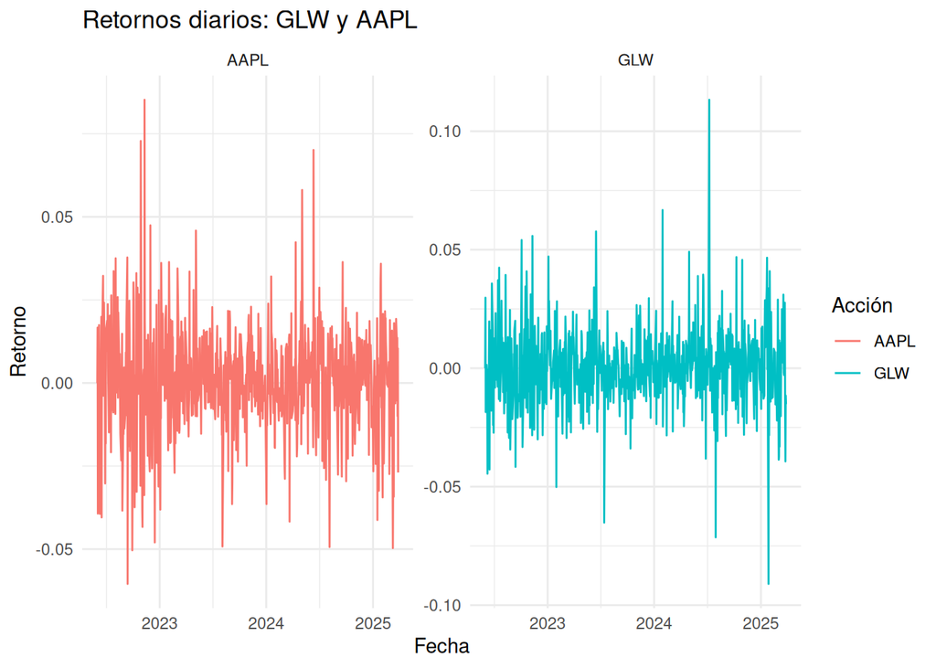

```r
ggplot(datos_g$ret, aes(x = date, y = ret, color = symbol)) +
  geom_line() +
  facet_wrap(~symbol, scales = "free_y") +
  labs(title = "Retornos diarios: GLW y AAPL", x = "Fecha", y = "Retorno", color = "Acción") +
  theme_minimal()
```

**Interpretación:** Se compara la volatilidad diaria de ambas acciones a lo largo del periodo.

## 12.4 Portafolio de media varianza

```r
mv_g <- min_varianza(datos_g$ret_xts, num_port = 5000)
weights_media_g <- mv_g$weights
sigma_annual_g  <- sqrt(diag(mv_g$cov_mat))
mu_annual_g     <- mv_g$mean_ret * 252
mv_g$cov_mat
```

```
##             GLW       AAPL
## GLW  0.07212198 0.02658615
## AAPL 0.02658615 0.06660769
```

```r
mv_g$media_var
```

| GLW | AAPL | Return | Risk | SharpeRatio |
| --- | --- | --- | --- | --- |
| 0.4677436 | 0.5322564 | 0.1412908 | 0.2188302 | 0.6456641 |

**Interpretación:** Se obtiene la combinación GLW/AAPL de mínima varianza entre 5,000 portafolios simulados.

## 12.5 Distribución de $1 millón de dólares

```r
shares_g <- investment * weights_media_g / latest_prices_g
shares_g
```

```
##       GLW      AAPL
## 10388.512  2457.688
```

**Interpretación:** Número de acciones de GLW y AAPL que se compran con USD 1 millón según los pesos óptimos.

## 12.6 Simulación MGB (5000 simulaciones, 8 trimestres)

```r
portfolio_sim_g <- simular_portafolio(latest_prices_g, shares_g, mu_annual_g, sigma_annual_g,
                                      Nsim = Nsim, trimestres = trimestres)
sim_summary_g <- tibble(Trimestre = 0:trimestres, Valor_Esperado = rowMeans(portfolio_sim_g))
sim_summary_g
```

| Trimestre | Valor_Esperado |
| --- | --- |
| 0 | 1000000 |
| 1 | 1033808 |
| 2 | 1070048 |
| 3 | 1107068 |
| 4 | 1143918 |
| 5 | 1182094 |
| 6 | 1221601 |
| 7 | 1264288 |
| 8 | 1305195 |

**Interpretación:** Proyección trimestral del valor esperado del portafolio GLW/AAPL a 2 años mediante MGB.

## 12.7 Análisis de Retorno, Volatilidad y VaR

```r
analisis_trimestral_g <- analizar_var(portfolio_sim_g)
rm(portfolio_sim_g); invisible(gc())

kable(analisis_trimestral_g, caption = "Análisis Trimestral del Portafolio Simulado (GLW / AAPL)") %>%
  kable_styling()
```

Análisis Trimestral del Portafolio Simulado (GLW / AAPL)

| Trimestre | Retorno Esperado (%) | Volatilidad Esperada (%) | VaR 1% (USD) | VaR 5% (USD) |
| --- | --- | --- | --- | --- |
| 1 | 2.894 | 9.296 | 197661.0 | 125659.4 |
| 2 | 3.025 | 9.452 | 182472.9 | 122510.7 |
| 3 | 2.969 | 9.434 | 192448.1 | 125468.8 |
| 4 | 2.834 | 9.657 | 193851.6 | 128372.3 |
| 5 | 2.809 | 9.587 | 192201.8 | 129560.4 |
| 6 | 2.863 | 9.242 | 186650.1 | 124457.0 |
| 7 | 2.933 | 9.556 | 193534.2 | 126231.8 |
| 8 | 2.748 | 9.623 | 196266.9 | 130686.6 |

**Interpretación:** Retorno, volatilidad y VaR al 1% y 5% por trimestre para el portafolio GLW/AAPL.

## 12.8 Opciones Europeas y Americanas (Árbol Binomial)

```r
option_data_g <- valuar_opciones(latest_prices_g, sigma_annual_g, r, T_opc, n)
kable(option_data_g, caption = "Opciones Europeas y Americanas GLW / AAPL - Árbol Binomial") %>%
  kable_styling()
```

Opciones Europeas y Americanas GLW / AAPL - Árbol Binomial

| Accion | Spot | Call_Euro | Call_Amer |
| --- | --- | --- | --- |
| GLW | 45.02508 | 8.786058 | 8.786058 |
| AAPL | 216.56793 | 40.970245 | 40.970245 |

**Interpretación:** Valuación de calls europeas y americanas ATM a 2 años con árbol binomial de 3 pasos.

## 12.9 Rolling trimestral de opciones Call Europeas

```r
call_rolling_g <- rolling_calls(sim_summary_g$Valor_Esperado, sigma_annual_g, r, T_opc, n, trimestres)
kable(call_rolling_g, caption = "Rolling Trimestral de Opciones Call Europeas (GLW / AAPL)") %>%
  kable_styling()
```

Rolling Trimestral de Opciones Call Europeas (GLW / AAPL)

| Trimestre | Accion | Valor_Call |
| --- | --- | --- |
| 1 | GLW | 195137.0 |
| 1 | AAPL | 189179.6 |
| 2 | GLW | 201734.1 |
| 2 | AAPL | 195575.4 |
| 3 | GLW | 208805.8 |
| 3 | AAPL | 202431.2 |
| 4 | GLW | 216029.9 |
| 4 | AAPL | 209434.7 |
| 5 | GLW | 223220.7 |
| 5 | AAPL | 216406.0 |
| 6 | GLW | 230670.3 |
| 6 | AAPL | 223628.2 |
| 7 | GLW | 238379.6 |
| 7 | AAPL | 231102.1 |
| 8 | GLW | 246709.3 |
| 8 | AAPL | 239177.5 |

**Interpretación:** Evaluación trimestral de las calls con strike ajustado al spot, para la cobertura dinámica.

## 12.10 Visualización del árbol binomial (Call Europea GLW)

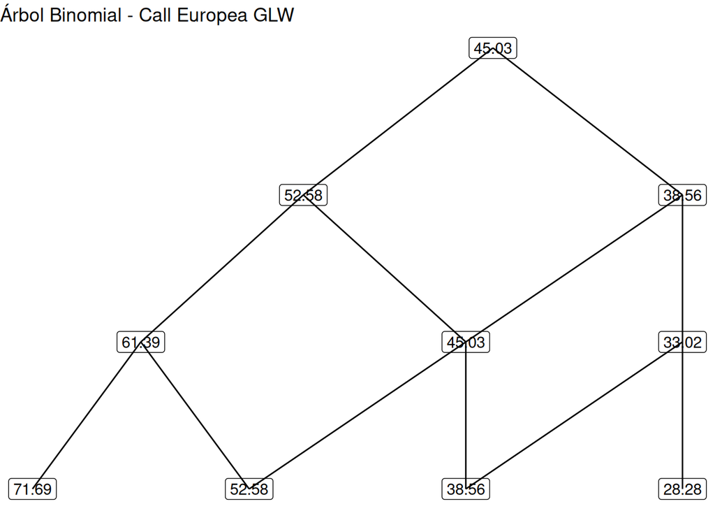

```r
graficar_arbol(latest_prices_g["GLW"], sigma_annual_g["GLW"], T = 1, n = 3,
               titulo = "Árbol Binomial - Call Europea GLW")
```

**Interpretación:** Estructura del árbol binomial de precios para GLW.

## 12.11 Cobertura financiera y distribución entre activos

```r
cobertura_dist_g <- cobertura_pct * investment * weights_media_g
cobertura_dist_g
```

```
##    GLW   AAPL
## 397582 452418
```

**Interpretación:** Se cubre el 85% del portafolio, distribuido entre GLW y AAPL según los pesos de mínima varianza.